# Video Games Sales

## by Omer Alabas

## Investigation Overview

> My main goal in this presentation is to show which gaming platform has the most supported games in that platform. Diffrent games generations has been taken into consideration in this investigation. Also I want to show which region has the most games sales in the golbe.

## Dataset Overview

> This dataset was taken from kaggle.com. It contains a list of video games that sold more than 100,000 copies. It was generated by a scrape of vgchartz.com. It has more than 16,500 rows in total with each raw represting a game with the sales of that according to each region. It satisfies all Udacity rules for choosing a personal dataset. This data was last updated in 2017.

## What is the plaform with the most games?

> The figure below shows that DS (Nintendo DS) and PS2 (Playstation 2) have the most games in this dataset. However this could be misleading since the dataset has records that goes back to 1980! So it would make sense that older platforms have more supporting games than newer ones.  
> To solve this issue we will separate our data set into two dataframes, df_old_gen and df_new_gen. We will take 2007 as our breaking point (since 2007 is the median of the data).

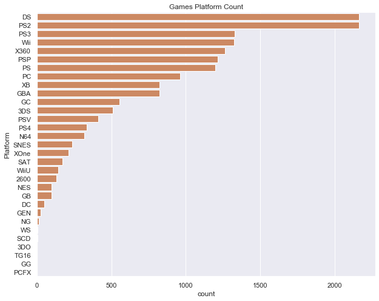

## What is the plaform with the most games from 1980 to 2007?

> We can see in the graph below that PS2 is the platform with the most games by far, followed by PS1. Looks like Sony was mass producing games in this period of time.

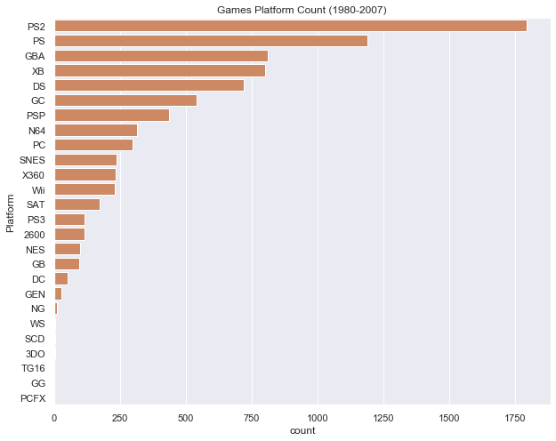

## What is the plaform with the most games from 2007 to 2017?

> We can see in the graph below that DS is the platform with the most games followed by PS3 follwed by Wii. I did not expect Nintendo to produse this huge amount of games!

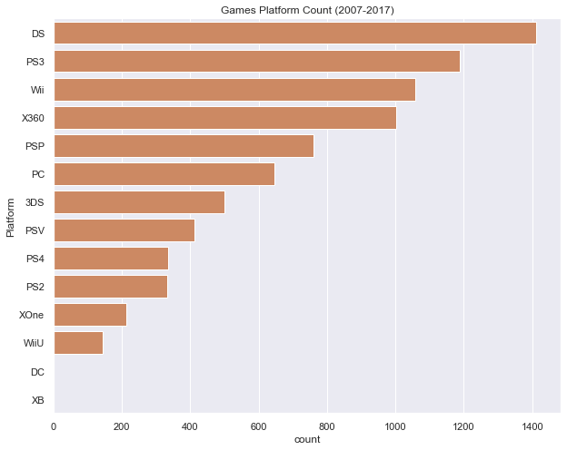

## What region have the most sales?

> From the below graph it apears that North America has the most sales. It contributes to almost half of the global sales! Europe comes second with 27.3% of the global sales. Finally Japan and other regions come last.

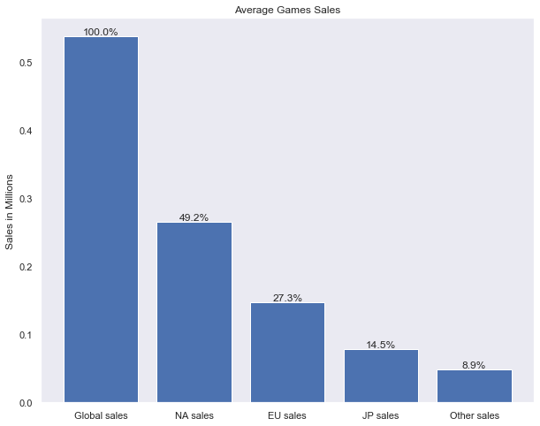

## What is the genre with the most games?

> Action is the most common game genre according to this dataset. This is no surprise since most people love Action games and movies.

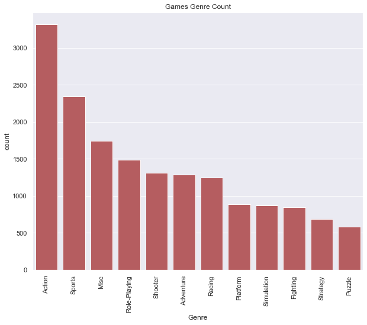

## The change of sales over time

> This is very intresting! According to the graph, the old generation apears to have higher sales than recent years! There has to be a reason for that. My guess is that sincne in recent years the games are more, then maybe many games with low sales are bringing the mean of sales down. Also you can see the long range of data in old years meaning that the data is scattared.

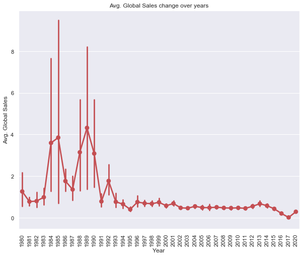